# Week 8 Assignment: Instructor Answer Key

This key provides model responses, not mandatory wording. Other accurate, well-supported responses may earn full credit. The code follows the instructor master script. Questions 2 and 7 include example AI prompts; students’ actual prompts and responses will differ.

## Question 1: Import and inspect the data

The code imports all 172 participants, summarizes the variables, and labels the three playback conditions. The frequency table should show 57 participants at 1x, 58 at 1.5x, and 57 at 2.5x.

```r
library(ggplot2)
library(performance)
library(psych)
library(rstatix)
library(summarytools)

# Assignment data URL (available after assignment8.csv is pushed to GitHub).
filepath <- "https://raw.githubusercontent.com/craigenders/psych250a/main/data/assignment8.csv"
assign8 <- read.csv(filepath, stringsAsFactors = TRUE)

dfSummary(assign8)
```

```
## Data Frame Summary
## assign8
## Dimensions: 172 x 7
## Duplicates: 0
##
## -----------------------------------------------------------------------------------------------------------------
## No   Variable          Stats / Values            Freqs (% of Valid)    Graph                 Valid      Missing
## ---- ----------------- ------------------------- --------------------- --------------------- ---------- ---------
## 1    Participant       Mean (sd) : 118 (67.2)    172 distinct values         :   . :   . :   172        0
##      [integer]         min < med < max:                                : : : : : : :   : :   (100.0%)   (0.0%)
##                        1 < 118.5 < 231                                 : : : : : : : : : :
##                        IQR (CV) : 114 (0.6)                            : : : : : : : : : :
##                                                                        : : : : : : : : : :
##
## 2    Age               Mean (sd) : 20.8 (3)      14 distinct values      : .                 172        0
##      [integer]         min < med < max:                                  : :                 (100.0%)   (0.0%)
##                        12 < 20 < 41                                      : :
##                        IQR (CV) : 2 (0.1)                                : :
##                                                                          : : .
##
## 3    VideoSpeed        Mean (sd) : 1 (0.8)       0 : 57 (33.1%)        IIIIII                172        0
##      [integer]         min < med < max:          1 : 58 (33.7%)        IIIIII                (100.0%)   (0.0%)
##                        0 < 1 < 2                 2 : 57 (33.1%)        IIIIII
##                        IQR (CV) : 2 (0.8)
##
## 4    TwoSpeeds         Min  : 0                  0 :  57 (33.1%)       IIIIII                172        0
##      [integer]         Mean : 0.7                1 : 115 (66.9%)       IIIIIIIIIIIII         (100.0%)   (0.0%)
##                        Max  : 1
##
## 5    ImmediateRecall   Mean (sd) : 60.1 (15.3)   60 distinct values          :               172        0
##      [integer]         min < med < max:                                      : : .           (100.0%)   (0.0%)
##                        20 < 59 < 93                                        . : : :
##                        IQR (CV) : 21.5 (0.3)                             . : : : :
##                                                                        . : : : : : : .
##
## 6    Delay             Mean (sd) : 9.2 (2.1)     11 distinct values          :               172        0
##      [integer]         min < med < max:                                      :               (100.0%)   (0.0%)
##                        4 < 9 < 15                                            : .
##                        IQR (CV) : 2 (0.2)                                    : : .
##                                                                            : : : : . . . :
##
## 7    DelayedRecall     Mean (sd) : 52.9 (14.8)   60 distinct values            : :           172        0
##      [integer]         min < med < max:                                      : : :           (100.0%)   (0.0%)
##                        17 < 54.5 < 93                                        : : :
##                        IQR (CV) : 19.5 (0.3)                             . : : : :
##                                                                        . : : : : : : .
## -----------------------------------------------------------------------------------------------------------------
```

```r
assign8$VideoSpeed <- factor(assign8$VideoSpeed,
                            levels = c(0, 1, 2),
                            labels = c("1x", "1.5x", "2.5x"))
freq(assign8$VideoSpeed)
```

```
## Frequencies
## assign8$VideoSpeed
## Type: Factor
##
##               Freq   % Valid   % Valid Cum.   % Total   % Total Cum.
## ----------- ------ --------- -------------- --------- --------------
##          1x     57     33.14          33.14     33.14          33.14
##        1.5x     58     33.72          66.86     33.72          66.86
##        2.5x     57     33.14         100.00     33.14         100.00
##        <NA>      0                               0.00         100.00
##       Total    172    100.00         100.00    100.00         100.00
```

## Question 2: Generate a graph with AI

**Example final prompt**

> I have an R data frame named assign8. Each row represents one participant. DelayedRecall is the percentage correct on a delayed-recall test. VideoSpeed is a factor with levels labeled “1x”, “1.5x”, and “2.5x”, in that order. Write R code using only base R and ggplot2 to create a bar graph of mean DelayedRecall for each VideoSpeed group. Place a dot at the top of each bar to mark its mean and error bars extending above and below the mean to show its 95% confidence interval. Calculate each interval using that group’s sample size and standard deviation and the appropriate t critical value. Label the horizontal axis “Video Playback Speed” and the vertical axis “Delayed Recall (% Correct)”. Start the bar chart’s vertical axis at zero. The data are already loaded and VideoSpeed is already labeled; do not simulate data. Include comments explaining the calculations and graph layers.

**Example working code**

```r
# One example of working code for the AI graph task, using base R and ggplot2.

means <- tapply(assign8$DelayedRecall, assign8$VideoSpeed, mean)
sds <- tapply(assign8$DelayedRecall, assign8$VideoSpeed, sd)
ns <- tapply(assign8$DelayedRecall, assign8$VideoSpeed, length)
ses <- sds / sqrt(ns)
moe <- qt(.975, df = ns - 1) * ses

plotdata <- data.frame(
  VideoSpeed = factor(names(means), levels = names(means)),
  N = as.numeric(ns), Mean = as.numeric(means), SD = as.numeric(sds),
  SE = as.numeric(ses), Lower = as.numeric(means - moe),
  Upper = as.numeric(means + moe))
print(plotdata)
```

```
##   VideoSpeed  N     Mean       SD       SE    Lower    Upper
## 1         1x 57 58.26316 12.91805 1.711037 54.83554 61.69078
## 2       1.5x 58 51.56897 14.62168 1.919920 47.72439 55.41354
## 3       2.5x 57 48.87719 15.49317 2.052120 44.76630 52.98808
```

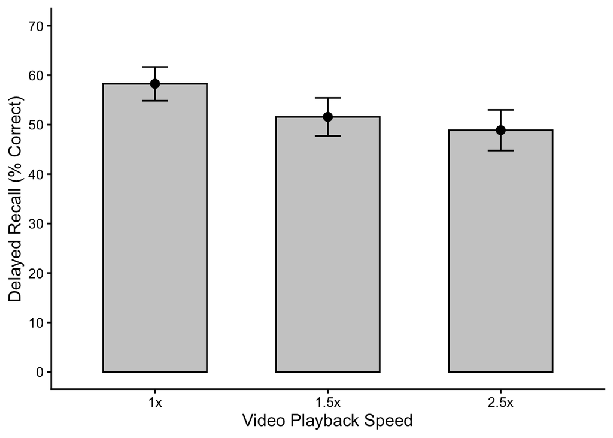

```r
ci_plot <- ggplot(plotdata, aes(x = VideoSpeed, y = Mean)) +
  geom_col(fill = "gray80", color = "black", width = 0.6) +
  geom_point(size = 3) +
  geom_errorbar(aes(ymin = Lower, ymax = Upper), width = 0.15) +
  scale_y_continuous(breaks = seq(0, 100, 10)) +
  coord_cartesian(ylim = c(0, 70)) +
  labs(x = "Video Playback Speed", y = "Delayed Recall (% Correct)") +
  theme_classic(base_size = 14)
print(ci_plot)
```

## Question 3: Connect the graph to the F ratio

The F statistic compares between-group variation with within-group variation. Differences among the bar heights reflect differences among the sample means and therefore contribute to between-group variation. The confidence intervals reflect the precision of those means; with sample sizes fixed, wider intervals indicate greater within-group variation. If the bar heights became farther apart while sample sizes and interval widths remained unchanged, between-group variation would increase relative to within-group variation, and F would increase. If the intervals became wider while sample sizes and bar heights remained unchanged, within-group variation would increase while between-group variation remained unchanged, and F would decrease.

## Question 4: Descriptives and ANOVA analyses

```r
describeBy(DelayedRecall ~ VideoSpeed, data = assign8)
```

```
##
##  Descriptive statistics by group
## VideoSpeed: 1x
##               vars  n  mean    sd median trimmed mad min max range skew kurtosis   se
## DelayedRecall    1 57 58.26 12.92     61   58.79 8.9  18  93    75 -0.5     0.88 1.71
## --------------------------------------------------------------------------------------------------------------
## VideoSpeed: 1.5x
##               vars  n  mean    sd median trimmed   mad min max range skew kurtosis   se
## DelayedRecall    1 58 51.57 14.62   53.5   51.94 11.12  17  87    70 -0.2     0.09 1.92
## --------------------------------------------------------------------------------------------------------------
## VideoSpeed: 2.5x
##               vars  n  mean    sd median trimmed   mad min max range  skew kurtosis   se
## DelayedRecall    1 57 48.88 15.49     49   49.04 19.27  19  81    62 -0.05    -0.94 2.05
```

```r
anovaresults <- aov(DelayedRecall ~ VideoSpeed, data = assign8)
summary(anovaresults)
```

```
##              Df Sum Sq Mean Sq F value  Pr(>F)
## VideoSpeed    2   2665  1332.3   6.438 0.00202 **
## Residuals   169  34973   206.9
## ---
## Signif. codes:  0 '***' 0.001 '**' 0.01 '*' 0.05 '.' 0.1 ' ' 1
```

```r
welchresults <- oneway.test(DelayedRecall ~ VideoSpeed, data = assign8)
welchresults
```

```
##
##  One-way analysis of means (not assuming equal variances)
##
## data:  DelayedRecall and VideoSpeed
## F = 6.8769, num df = 2.00, denom df = 112.03, p-value = 0.001524
```

```r
r2(anovaresults)
```

```
## # R2 for Anova Regression
##        R2: 0.071
##   adj. R2: 0.060
```

**Expected results:** The standard ANOVA gives F(2, 169) = 6.44, p = .00202; Welch’s ANOVA gives F(2, 112.03) = 6.88, p = .00152. R-squared is approximately .071. The requested effect size is the unadjusted R-squared, not the adjusted value of approximately .060.

## Question 5: Interpret the p-value and R-squared

If the three playback speed conditions have the same population mean delayed recall, and the standard ANOVA’s assumptions hold, the probability of obtaining an F statistic at least as large as the observed 6.44 is approximately .002, or 0.2%, across repeated samples. This small probability provides evidence against the null hypothesis of equal population means; the overall test is statistically significant at the .05 level. It establishes evidence that at least one population mean differs, but does not identify which groups differ. R-squared = .071 means that differences among the playback speed groups account for approximately 7.1% of the observed variation in delayed-recall scores. The p-value quantifies evidence against equal population means, whereas R-squared describes the magnitude of the association between playback speed and delayed recall. A statistically significant result does not by itself indicate how much variation the groups account for.

## Question 6: Compare standard and Welch ANOVA

The group standard deviations are 12.92, 14.62, and 15.49 percentage points for the 1x, 1.5x, and 2.5x conditions, respectively. These are reasonably similar, although the fastest condition has the largest spread; its SD is about 1.20 times the slowest condition’s SD. The standard ANOVA gives F(2, 169) = 6.44, p = .00202, and Welch’s ANOVA gives F(2, 112.03) = 6.88, p = .00152. Both tests provide strong evidence against equal population means, and their F statistics and p-values are similar. Allowing the population variances to differ therefore does not materially change the overall conclusion in these data. This agreement supports the stability of the conclusion but does not establish that the population variances are equal.

## Question 7: Evaluate assumptions with AI

**Example final prompt**

> A study assigned 172 participants to three video playback speed conditions: 1x, 1.5x, and 2.5x. Each participant belongs to one condition and contributes one delayed-recall score, expressed as percentage correct, to a standard one-way ANOVA. The descriptive statistics are shown below. Kurtosis is excess kurtosis, for which a normal distribution has a value of zero.

> | Group | N | Mean | SD | Median | Minimum | Maximum | Skewness | Excess kurtosis |
> | --- | --- | --- | --- | --- | --- | --- | --- | --- |
> | 1x | 57 | 58.26 | 12.92 | 61.0 | 18 | 93 | -0.50 | 0.88 |
> | 1.5x | 58 | 51.57 | 14.62 | 53.5 | 17 | 87 | -0.20 | 0.09 |
> | 2.5x | 57 | 48.88 | 15.49 | 49.0 | 19 | 81 | -0.05 | -0.94 |

> Evaluate whether the assumptions of the standard one-way ANOVA are satisfied, using specific evidence from these summaries and the study design. Address within-group normality, homogeneity of population variances, and independence of observations. Distinguish evidence about whether an assumption holds from evidence about whether departures would materially affect the F test. Support your assessment with published methodological research, providing complete citations and links or DOIs. Explain how the conditions examined in those studies apply here and where they may not. Identify assumptions or distributional features that cannot be evaluated from this information and the additional information needed. Do not invent diagnostic results or treat descriptive statistics as proof that an assumption holds.

**Example supplemental paragraph**

We examined group-specific sample sizes, standard deviations, skewness, and excess kurtosis to assess the assumptions of the one-way ANOVA. Group sizes were nearly equal (57, 58, and 57), and standard deviations ranged from 12.92 to 15.49, indicating relatively similar observed dispersion, although these summaries do not establish equality of population variances. Skewness ranged from -0.50 to -0.05 and excess kurtosis from -0.94 to 0.88, suggesting modest departures from normality. Blanca et al. (2017) found that the three-group ANOVA F test maintained Type I error control across a broad range of nonnormal distributions in simulations that assumed equal population variances. Their simulated skewness and kurtosis values included the range observed here, supporting limited concern about nonnormality while leaving the other assumptions to be assessed separately. Summary statistics cannot exclude unusual distributional features or influential observations; examination of the raw distributions would be needed to assess these more fully. Each participant contributed one delayed-recall score to one condition, which avoids repeated observations within this analysis, but independence also depends on the absence of clustering or other dependence in data collection and cannot be verified from the descriptive statistics alone.

**Methodological source:** Blanca, M. J., Alarcón, R., Arnau, J., Bono, R., & Bendayan, R. (2017). Non-normal data: Is ANOVA still a valid option? *Psicothema, 29*(4), 552–557. https://doi.org/10.7334/psicothema2016.383.

**Instructor note:** This is one defensible response, not a required set of sources or conclusions. Students should accurately represent the methodological work they cite and distinguish robustness from literal satisfaction of assumptions. They should not claim to have conducted diagnostics that their response does not document.

## Question 8: Apply inference by eye

For two independent groups, the inference-by-eye rule suggests statistical significance when the overlap of the 95% confidence intervals is less than approximately half the average margin of error. The 1x interval is [54.84, 61.69], the 1.5x interval is [47.72, 55.41], and the 2.5x interval is [44.77, 52.99]. The 1x and 1.5x intervals overlap only slightly, by approximately 0.58 percentage points, which is less than half their average margin of error (approximately 1.82); this suggests higher mean delayed recall at 1x. The 1x and 2.5x intervals do not overlap, also suggesting higher mean delayed recall at 1x. In contrast, the 1.5x and 2.5x intervals overlap substantially, by approximately 5.26 points, exceeding half their average margin of error (approximately 1.99); this comparison does not provide evidence of different population means. The last result does not establish that the population means are identical.

**Instructor note:** These overlap calculations make the rationale explicit; students need not calculate them to this precision. The visual rule approximates individual two-group tests and does not itself adjust for multiple comparisons.

## Question 9: Tukey tests and pairwise effect sizes

```r
TukeyHSD(anovaresults)
```

```
##   Tukey multiple comparisons of means
##     95% family-wise confidence level
##
## Fit: aov(formula = DelayedRecall ~ VideoSpeed, data = assign8)
##
## $VideoSpeed
##                diff        lwr        upr     p adj
## 1.5x-1x   -6.694192 -13.038308 -0.3500765 0.0359605
## 2.5x-1x   -9.385965 -15.757604 -3.0143256 0.0018176
## 2.5x-1.5x -2.691773  -9.035888  3.6523433 0.5758226
```

```r
cohens_d(DelayedRecall ~ VideoSpeed, data = assign8)
```

```
## # A tibble: 3 × 7
##   .y.           group1 group2 effsize    n1    n2 magnitude
## * <chr>         <chr>  <chr>    <dbl> <int> <int> <ord>
## 1 DelayedRecall 1x     1.5x     0.485    57    58 small
## 2 DelayedRecall 1x     2.5x     0.658    57    57 moderate
## 3 DelayedRecall 1.5x   2.5x     0.179    58    57 negligible
```

```r
# TukeyHSD reports later factor level minus earlier factor level.
# cohens_d reports group1 minus group2, so signs are reversed here.
# Cohen's d uses each pair's pooled SD (the lab's default).
```

Delayed recall is significantly higher at 1x than at 1.5x (mean difference = 6.69 percentage points, Tukey-adjusted p = .036) and at 2.5x (mean difference = 9.39 points, adjusted p = .0018). The difference between 1.5x and 2.5x is not statistically significant (mean difference = 2.69 points, adjusted p = .576). All three conclusions agree with the inference-by-eye judgments from Question 8. The Cohen’s d values add information about the magnitude of the differences in pooled standard deviation units: 0.49 for 1x versus 1.5x, 0.66 for 1x versus 2.5x, and 0.18 for 1.5x versus 2.5x. Thus, the largest difference is between the slowest and fastest conditions, and the difference between the two faster conditions is comparatively small. These effect sizes describe the size of each difference rather than serving as another test of statistical significance.

**Sign convention:** The prose reports slower minus faster playback. R’s Tukey output uses faster minus slower playback for these factor levels, so its differences are negative. The substantive conclusions are unchanged.

## Question 10: Translational abstract

This study tested whether the speed at which people watch lecture videos affects how much they remember about nine days later. People who watched at normal speed remembered about 58% of the material, compared with 52% for those who watched at 1.5 times normal speed and 49% for those who watched at 2.5 times normal speed. These differences were larger than chance alone would be expected to produce, so playback speed made a real difference in how much people remembered. Comparing the groups two at a time, people who watched at normal speed remembered more than people who watched at either faster speed, but the study could not establish a difference between the two faster speeds. The normal-speed advantage of about 7 to 9 percentage points was moderate in size, about half to two-thirds of the typical spread in scores, whereas the 3-point difference between the two faster speeds was small, less than a fifth of the typical spread. Playback speed accounted for about 7% of the differences in recall among participants, so many other factors also influence how much people remember. Overall, watching lectures at faster speeds led to poorer long-term memory of the material, and learners who want to retain what they watch may be better off watching at normal speed.

## Question 11: Complete AI chat log

This question is ungraded. The response should contain the student’s actual complete conversation for Questions 2 and 7, including revisions and follow-up exchanges. There is no single optimal transcript, and an invented transcript would not satisfy the requirement.